# STAT508_DAA9

Ada Lazuli

April 5th, 2026

## Preliminary Code to Subset the Dataset

```r
#This code requires the NHANES package to be loaded (add it to your Front Matter)
df <- NHANES[ , -c(1,2,5, 6, 7, 8, 11, 12, 16, 18, 19, 22, 23, 27:39, 41, 43:45, 47:51, 53:76)]
```

## Problem 1 - Initial Exploration and Preliminaries

#### Part a. - Create an appropriate plot for showing the distribution of the levels in the HealthGen variable. Support the plot by also reporting the number of times each level is found in df.

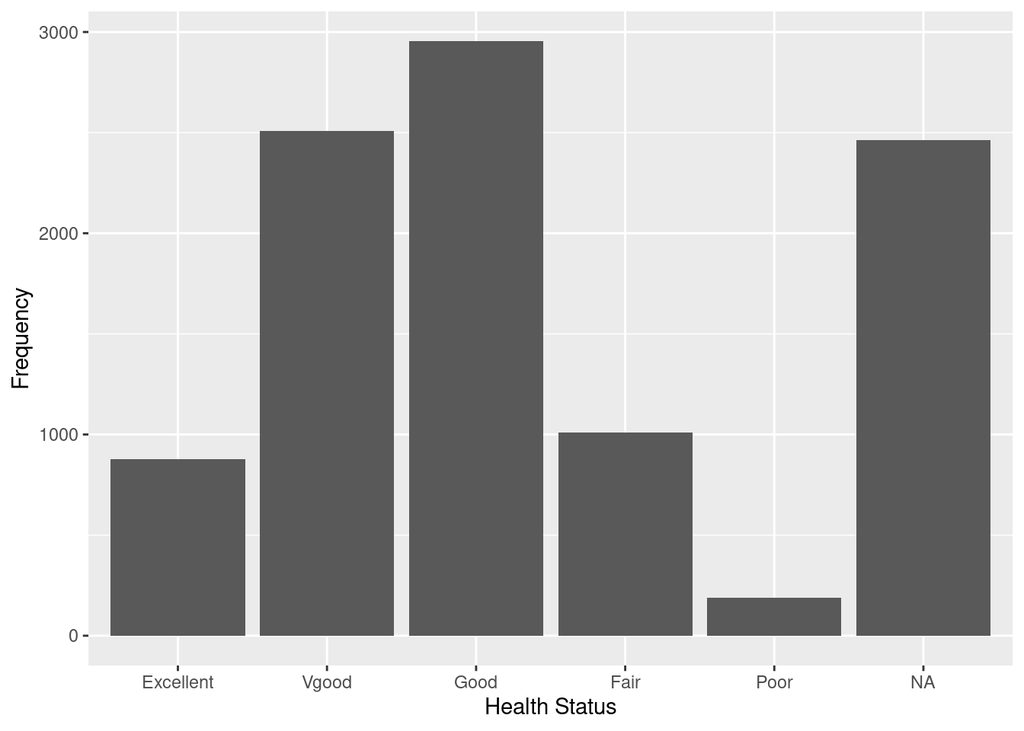

```r
ggplot(df, aes(x = HealthGen)) + geom_bar() + labs(y = "Frequency", x = "Health Status")
```

Additionally, data is missing for 2461 rows in the data.

#### Part b. - Which variable in the df dataset contains the greater number of missing values?

```r
apply(X = df, MARGIN = 2, FUN = function(x) sum(is.na(x)))
```

```
##        Gender           Age     Education MaritalStatus       Poverty
##             0             0          2779          2769           726
##     HomeRooms       HomeOwn        Weight        Height           BMI
##            69            63            78           353           366
##         Pulse      BPSysAve      BPDiaAve      Diabetes     HealthGen
##          1437          1449          1449           142          2461
##     Depressed    PhysActive
##          3327          1674
```

The depressed variable contains the greatest number of missing values.

#### Part c. - Create a new object named df2 that contains the adults with complete data.

```r
df2 <- na.omit(df %>% filter(Age >= 18))
nrow(df2)
```

```
## [1] 5867
```

#### Part d. - Using a seed of 123, perform an 80/20 training/validation split of the df2 dataset.

```r
set.seed(123)
trainInd <- sample(1:nrow(df2), floor(0.80 * nrow(df2)))
set.seed(NULL)

Train <- df2[trainInd, ]
Validation <- df2[-trainInd, ]
```

## Problem 2 - Classification Tree

#### Part a. - Grow a classification tree for predicting the self-reported health status using all other variables in the dataset. To grow the tree, use a complexity parameter (cp) value of 0.003. Implement 10-fold cross validation based on a seed of 123 and produce the cptable.

```r
set.seed(123)
tree_model1 <- rpart(HealthGen ~ . , data = Train, method = "class", cp = 0.003, xval = 10)
tree_model1$cptable
```

```
##             CP nsplit rel error    xerror       xstd
## 1  0.050369849      0 1.0000000 1.0000000 0.01179633
## 2  0.018668545      1 0.9496302 0.9605495 0.01190539
## 3  0.008218856      2 0.9309616 0.9556182 0.01191700
## 4  0.006340261      6 0.8960902 0.9348362 0.01196103
## 5  0.005283551      8 0.8834097 0.9137020 0.01199777
## 6  0.004755195      9 0.8781261 0.9193378 0.01198876
## 7  0.004696489     15 0.8495949 0.9140542 0.01199722
## 8  0.003522367     18 0.8355055 0.9063050 0.01200873
## 9  0.003170130     19 0.8319831 0.9045439 0.01201120
## 10 0.003111424     24 0.8161324 0.9024304 0.01201408
## 11 0.003000000     30 0.7974639 0.8999648 0.01201735
```

#### Part b. - What is the optimal value of the complexity parameter based on the one standard error (1se) rule?

```r
cpRow <- which.min(tree_model1$cptable[ , "xerror"])
target <- tree_model1$cptable[ , "xerror"][cpRow] +tree_model1$cptable[ , "xstd"][cpRow]
cpRow1se <- which(tree_model1$cptable[ , "xerror"] < target)[1]
cpChoice1se <- tree_model1$cptable[ , "CP"][cpRow1se]
cpChoice1se
```

```
##           8
## 0.003522367
```

The optimal complexity parameter is 0.0035224

#### Part c. - Prune the tree using the complexity parameter from the 1se rule. Create a visualization of the pruned tree.

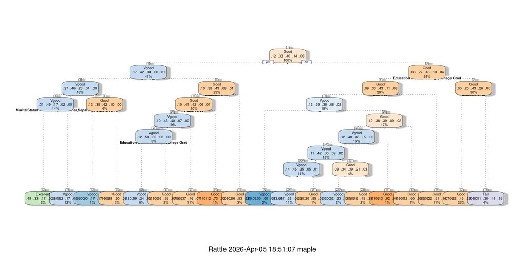

```r
tree_model1_pruned <- prune(tree_model1, cp=cpChoice1se)
fancyRpartPlot(tree_model1_pruned, cex=0.4)
```

#### Part d. - Using the pruned tree, report the validation set accuracy and create a confusion matrix summarizing the results of the predictions on the validation data.

```r
predHealth <- predict(tree_model1_pruned, newdata = Validation, type = "class")

tree_model_accuracy <- mean(predHealth == Validation$HealthGen)

table(predHealth, Validation$HealthGen)
```

```
##
## predHealth  Excellent Vgood Good Fair Poor
##   Excellent        13     7    6    2    0
##   Vgood            76   174   90   17    3
##   Good             49   206  352  123   11
##   Fair              0     1   18   19    7
##   Poor              0     0    0    0    0
```

The overall multi-class accuracy of the model is: 0.475

#### Part e. - Which class of HealthGen was most likely to be correctly predicted? Explain your reasoning.

```r
conditional_prob <- function(condition, truth, prediction) {
  numerator <- sum((truth == condition) & (prediction == condition))
  denominatior <- sum(truth == condition)
  return(numerator/denominatior)
}
conditional_prob("Excellent", Validation$HealthGen, predHealth)
```

```
## [1] 0.0942029
```

Using conditional probability to quantify the likelihood of predicting a health status given that health status:

1. Excellent: 0.0942029
2. Very Good: 0.4484536
3. Good: 0.7553648
4. Fair: 0.1180124
5. Poor: 0

Based on conditional probability, “good” health status is the most likely to be predicted correctly.

#### Part f. - Based on the pruned tree, which 3 variables were the most important?

```r
printout <- summary(tree_model1_pruned)
```

```r
printout$variable.importance
```

```
##       Poverty     Education           BMI        Weight      Diabetes
##     76.052039     60.632803     60.186137     40.862838     26.868392
##    PhysActive      BPDiaAve           Age        Height      BPSysAve
##     24.638759     21.760414     17.276391     17.177838     14.667301
##     HomeRooms MaritalStatus         Pulse     Depressed       HomeOwn
##     13.937380     12.699078     11.827167      6.426733      2.070884
```

The most important variables with their importance values are:

1. Poverty - 76.052
2. Education - 60.632
3. BMI - 60.186

## Problem 3 - k-Nearest Neighbors

#### Part a. - Prepare the data. Using only the quantitative variables in df2 as potential features, scale the features to have mean of 0 and a standard deviation of 1. Then, use a seed of 123 to perform an 80/20 training/validation split.

```r
df2_quant <- df2 %>% select(-Gender, -Education, -HomeOwn, -Diabetes, -Depressed, -PhysActive, -MaritalStatus)
xvars <- c("Age", "Poverty", "HomeRooms", "Weight", "Height", "BMI", "Pulse", "BPSysAve", "BPDiaAve")
df2_quant[, xvars] <- scale(x = df2_quant[, xvars], center = TRUE, scale = TRUE)
set.seed(123)
trainInd <- sample(1:nrow(df2_quant), floor(0.80 * nrow(df2_quant)))
set.seed(NULL)
Train <- df2_quant[trainInd, ]
Validation <- df2_quant[-trainInd, ]
```

#### Part b. - Implement kNN classification. Using values of k ranging from 1 to 20, create a plot showing the accuracy values based on predictions on the validation data as a function of k.

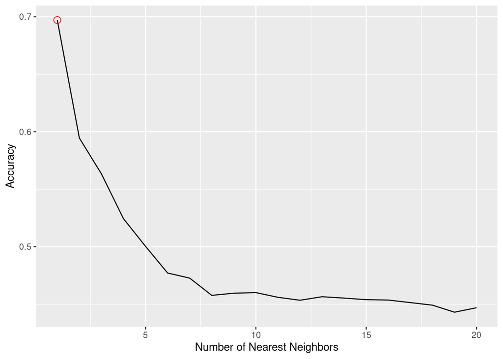

```r
num_folds <- 10
folds <- cut(x = 1:nrow(df2_quant), breaks = num_folds, labels = FALSE)

set.seed(123)
folds <- sample(folds)
set.seed(NULL)

maxK <- 20
accMatrix <- matrix(NA, nrow = num_folds, ncol = maxK)

for(i in 1:num_folds){
  valInd <- which(folds == i)
  Validation <- df2_quant[valInd,]
  Train <- df2_quant[-valInd,]

  for(j in 1:maxK){
    knnResTemp <-
    knn(train = Train[ , xvars, drop = FALSE],
        test = Validation[ , xvars, drop = FALSE],
        cl = Train$HealthGen,
        k = j)

    Validation <-
      Validation %>%
      mutate(predHealth = knnResTemp)

    pred<- factor(knnResTemp, levels = levels(df2_quant$HealthGen))
    truth <- factor(Validation$HealthGen, levels = levels(df2_quant$HealthGen))

    accMatrix[i,j] <- mean(pred == truth)
    }
}

accMeans <- apply(accMatrix, 2, mean)

tempDF <- data.frame(k = 1:maxK, Accuracy = accMeans)

ggplot(data = tempDF,
       mapping = aes(x = k, y = Accuracy)) +
  geom_line() +
  labs(x = "Number of Nearest Neighbors",
       y = "Accuracy") +
  geom_point(data = tempDF[which.max(accMeans), ],
             color = "red", shape = 1, size =3)
```

#### Part c. - Based on the plot in Part b., what value of k is optimal?

Based on the plot, it appears that 1 nearest neighbor yields the best performance.

#### Part d.- How does the predictive performance of the kNN classifier (at the optimal value of k) perform relative to the pruned classification tree’s predictive performance?

```r
# remaking the splits due to the cross fold variable overwrites
set.seed(123)
trainInd <- sample(1:nrow(df2_quant), floor(0.80 * nrow(df2_quant)))
set.seed(NULL)
Train <- df2_quant[trainInd, ]
Validation <- df2_quant[-trainInd, ]
optimalKnnRes <-  knn(train = Train[ , xvars, drop = FALSE],
        test = Validation[ , xvars, drop = FALSE],
        cl = Train$HealthGen,
        k = 1)
Validation <-
  Validation %>%
  mutate(predHealth = optimalKnnRes)

knn_accuracy <- mean(Validation$HealthGen == Validation$predHealth)
```

The accuracy for the KNN model with 1 nearest neighbor is 0.686 while the tree model had an accuracy of 0.475. The knn model scores 44.265% higher than the tree model.

#### Part e. - In Part b., we considered values of k ranging from 1 to 20. What happens if we tried to use values of k ranging from 1 to 25? Explain the error and how to correct it.

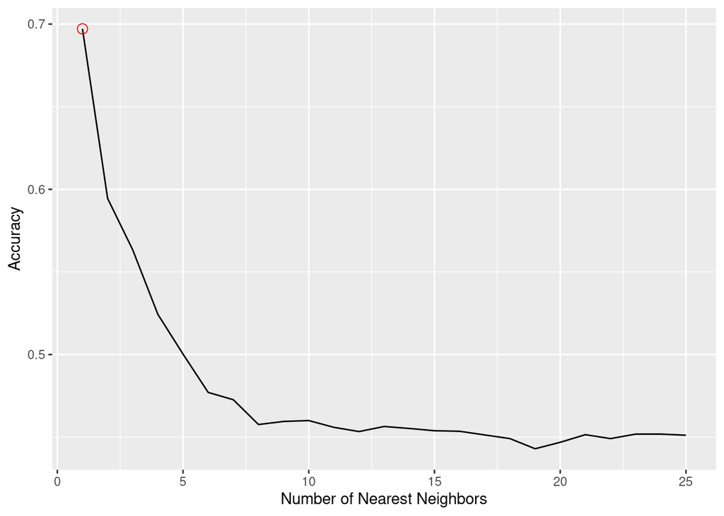

```r
num_folds <- 10
folds <- cut(x = 1:nrow(df2_quant), breaks = num_folds, labels = FALSE)

set.seed(123)
folds <- sample(folds)
set.seed(NULL)

maxK <- 25
accMatrix <- matrix(NA, nrow = num_folds, ncol = maxK)

for(i in 1:num_folds){
  valInd <- which(folds == i)
  Validation <- df2_quant[valInd,]
  Train <- df2_quant[-valInd,]

  for(j in 1:maxK){
    knnResTemp <-
    knn(train = Train[ , xvars, drop = FALSE],
        test = Validation[ , xvars, drop = FALSE],
        cl = Train$HealthGen,
        k = j)

    Validation <-
      Validation %>%
      mutate(predHealth = knnResTemp)

    pred<- factor(knnResTemp, levels = levels(df2_quant$HealthGen))
    truth <- factor(Validation$HealthGen, levels = levels(df2_quant$HealthGen))

    accMatrix[i,j] <- mean(pred == truth)
    }
}

accMeans <- apply(accMatrix, 2, mean)

tempDF <- data.frame(k = 1:maxK, Accuracy = accMeans)

ggplot(data = tempDF,
       mapping = aes(x = k, y = Accuracy)) +
  geom_line() +
  labs(x = "Number of Nearest Neighbors",
       y = "Accuracy") +
  geom_point(data = tempDF[which.max(accMeans), ],
             color = "red", shape = 1, size =3)
```

An error was not raised while increasing the `k` search range from 20 to 25. This is probably due to an error that was fixed previously, where one of the splits was missing all of the factors and an exception was raised during accuracy calculation.

This was fixed by explicitly specifying the factor levels using the full dataset:

```r
    pred<- factor(knnResTemp, levels = levels(df2_quant$HealthGen))
    truth <- factor(Validation$HealthGen, levels = levels(df2_quant$HealthGen))
```